# Predicting the Change in Avocado Prices

J. Alejandro Gelves

December 29, 2018

### Motivation

For the better part of 2018 avocado prices have been on the rise. The impact of higher prices has been felt by consumers and producers around the world. In 2018 the New York times reported that black markets and violence had emerged in countries such as New Zealand and Mexico due to higher prices. The effect has also had an impact on businesses such as Chipotle and Qdoba. Consider Chipotle. According to the Huffington post, Chipotle goes through 100,000 avocados a day (these have a life of about 1 week). Given a standard deviation of 50 cents in the price of avocados correctly timing the price of avocados could be the difference between gaining or lossing up to 1 million dollars in a week (3 standard deviations). As a consequence, correctly timing the purchase of avocados is of utmost importance to Chipotle and any other company that relies on avocados.  
This script proposes 3 models to predict the change in avocado prices. Mainly, Logistic, Quadratic Discriminant Analysis (QDA) and Linear Discriminant Analysis (LDA). The main finding is that QDA outperforms both LDA and Logistic regression when predicting the change in avocado prices. The script starts by going through some data cleaning and exploratory data analysis (EDA). It continues with variable selection and model creation. It concludes with model assesment and accuracy.

### Exploratory Data Analysis (EDA)

Start by loading the required packages and the data.

```r
library(dplyr)
library(boot)
library(zoo)
library(forecast)
library(Hmisc)
library(MASS)
library(glmulti)
library(reshape2)
data<-read.csv("avocado.csv")
```

Some cleaning needs to take place before the data is ready to be analyzed. By looking at the data it is clear that some variables are collinear. For example, volume and number of bags are in a way measuring the same concept. This script uses volume instead of bags to avoid the collinearity (analysis could also be done with bags if desired). The date column is separated into three variables (day, month and year) and a quarter variable is created. The names of the variables are changed to be more descriptive. Finally, the data set includes city, regional, and total US data. This script focuses on regional data (city data is included in regional data, so both regions and cities should not be used). The Hass Avocado Board data divides the US into 8 regions.

```r
data <- data[, -5:-11]    #getting rid of collinear columns.

# create quarters variables
date <- as.Date(data$Date)
yrQuater <- as.yearqtr(date, format = "Y-%m-%d")
Quarter <- format(yrQuater, format = "%q")
data <- cbind(data, Quarter)

# factorize avocado type. Changing Variable Names.
colnames(data)[4]<-"TotalVolume"
data$type <- as.factor(data$type)
colnames(data)[5]<- "AvocadoType"
#data$year <- as.factor(data$year)
colnames(data)[6]<- "Year"
data$region <- as.character(data$region)
colnames(data)[7]<- "Region"
colnames(data)[1]<- "Week"
#get rid of Dates, collinearity with Week.
data <- data[-2]

# Keeping only interested Regions (Rdata).
data %>% filter(Region == "West" | Region == "Southeast" | Region == "SouthCentral" | Region == "Northeast" |
                        Region == "Midsouth" | Region == "Plains" | Region == "GreatLakes" |
                  Region =="California") -> Rdata
Rdata$Region <- as.factor(Rdata$Region)
```

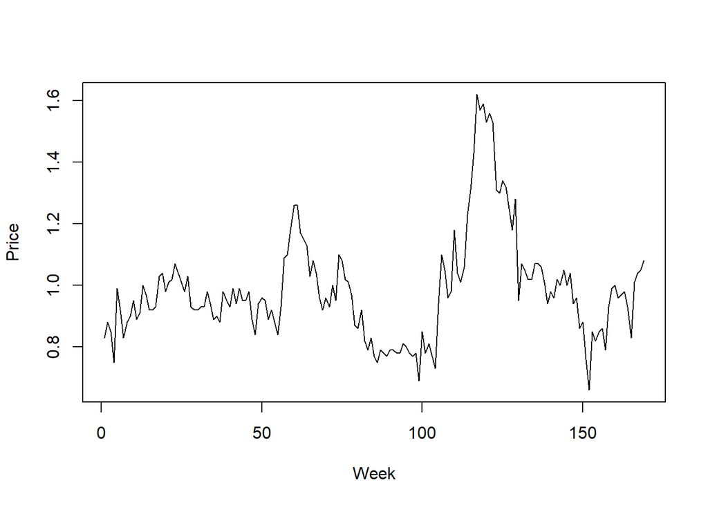

```r
Rdata%>%dplyr::filter(AvocadoType=="conventional",
                      Region=="West")->ts1california
plot.ts(ts1california$AveragePrice,xlab="Week",ylab="Price")
```

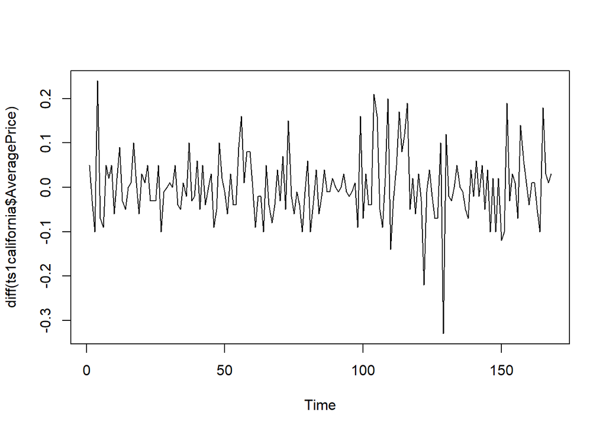

```r
plot.ts(diff(ts1california$AveragePrice))
```

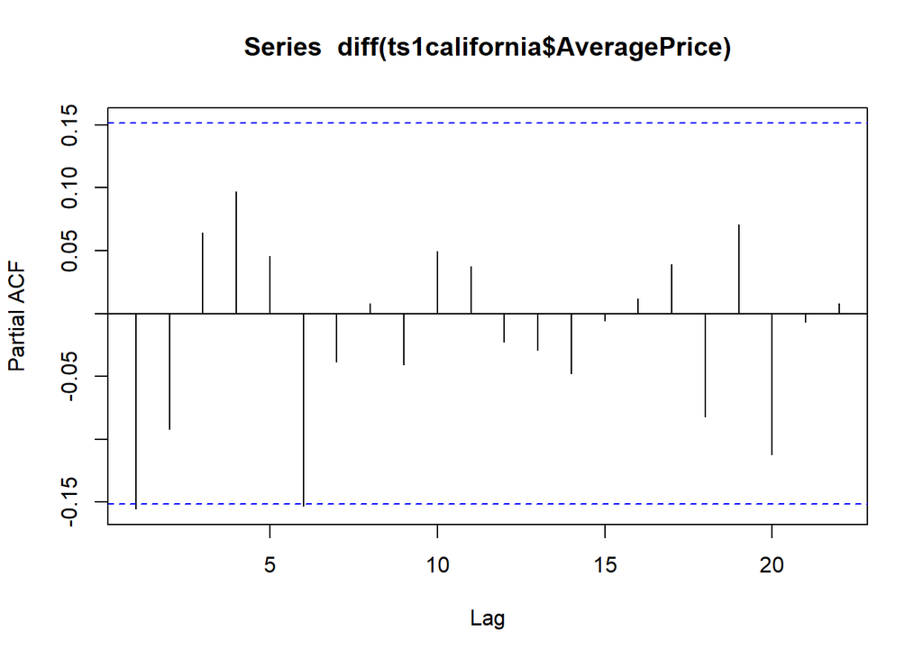

```r
pacf(diff(ts1california$AveragePrice))
```

The following two graphs yield some insight on avocado prices. First, avocado prices seem to be lowest in the south central region and highest in the northeastern region. Hence the region might be a good predictor of avocado prices. Second, the higher the price of the avocado the lower the volume sold in retail. Notice also that organic avocados are sold in lesser volumes and have more variation in price. Both the volume and the type of avocado should be a good predictor of the price.

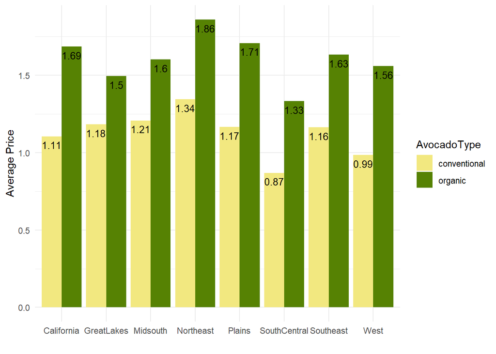

```r
Rdata%>%group_by(Region,AvocadoType)%>%summarise(region.mean=mean(AveragePrice))->means

library(ggplot2)
Bar<-ggplot(data=means, aes(x=Region, y=region.mean, fill=AvocadoType)) +
  geom_bar(stat="identity", position=position_dodge())+
  geom_text(aes(label=round(region.mean,2)), vjust=1.6, color="black",
            position = position_dodge(0.9), size=3.5)+
  scale_fill_brewer(palette="Paired")+
  theme_minimal()+scale_fill_manual(values=c("#F2E880","#568203"))+
  labs(x = "",y="Average Price")
plot(Bar)
```

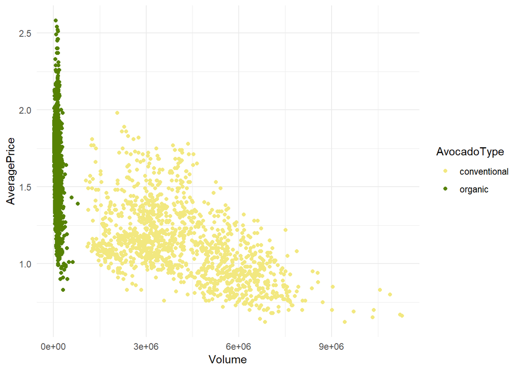

```r
scatter<-ggplot(Rdata, aes(x=TotalVolume, y=AveragePrice, col=AvocadoType)) +
  geom_point()+scale_color_manual(values=c("#F2E880","#568203"))+theme_minimal()+labs(x="Volume")
plot(scatter)
```

In sum, we have a set of time series. The first difference makes these time series stationary and possibly the first and second lags are good predictors of the change in the price of avocados. The type of avocado, the volume sold in retail, the quarter and the year (seasonality) should also be explored as predictors. Lag variables are created below for both volume and price.

```r
Rdata %>% group_by(Region,Year,AvocadoType) %>%
        mutate(Lag1AP = dplyr::lag(AveragePrice, n = 1, default = NA))%>%mutate(Lag1TV = dplyr::lag(TotalVolume, n = 1, default = NA))%>%
        mutate(Pchange=Lag1AP-AveragePrice) %>% mutate(Vchange=Lag1TV-TotalVolume)%>%
        mutate(Direction=as.factor(ifelse(Pchange>0,"Up","Down")))->Rdata
Rdata<-Rdata[complete.cases(Rdata),]
data%>%dplyr::select(Week,TotalVolume,AvocadoType,Year,Region,Quarter,AveragePrice)->RdataReg
Rdata%>%dplyr::select(Week,AvocadoType,Year,TotalVolume,Region,Quarter,Pchange,Direction,Week,Vchange)%>%
  mutate(Lag1 = dplyr::lag(Pchange, n = 1, default = NA)) %>% mutate(Lag2 = dplyr::lag(Pchange, n = 2, default = NA))%>%
  mutate(Lag3 = dplyr::lag(Pchange, n = 3, default = NA)) %>% mutate(Lag4 = dplyr::lag(Pchange, n = 4, default = NA))%>%
  mutate(VLag1 = dplyr::lag(Vchange, n = 1, default = NA)) %>% mutate(VLag2 = dplyr::lag(Vchange, n = 2, default = NA))%>%
  mutate(VLag3 = dplyr::lag(Vchange, n = 3, default = NA)) %>% mutate(VLag4 = dplyr::lag(Vchange, n = 4, default = NA))->Rdata
Rdata<-Rdata[complete.cases(Rdata),]
# TotalVolume is not known at time t+1.
Rdata%>%dplyr::select(-Vchange,-Pchange,-TotalVolume)->Rdata
```

### Variable Selection

glmmulti performs model selection using a criteria such as the AIC. A training set for the years 2015-2017 is created to search for the variables that yield the best model using the AIC. A Logistic regression is used as the model.

```r
train<-Rdata[Rdata$Year<2018,]

glmulti.glm.out <- glmulti(train$Direction ~ .,
                           data=train,
                           method="h",
                           crit = "aic",
                           confsetsize = 10,
                           fitfunction = "glm",
                           family = binomial,
                           level = 1,
                           plotty=FALSE,
                           report=FALSE)
glmulti.summary <- summary(glmulti.glm.out)
glmulti.summary$bestmodel
```

```
## [1] "train$Direction ~ 1 + AvocadoType + Quarter + Lag1 + Lag2 + Lag3 + "
## [2] "    VLag1 + VLag2"
```

```r
glmulti.summary$icvalues
```

```
##  [1] 2976.865 2977.442 2978.089 2978.230 2978.263 2978.432 2978.479
##  [8] 2978.778 2978.861 2978.885
```

An exhaustive search of a total of 16950 models yields a best model of: Direction=f(AvocadoType,Quarter,Lag1,Lag2,Lag3,Vlag1,Vlag2) Resulting in an AIC of 2976.9. These variables are used to assess the three models used to predict the change in prices.

### Predictions and Confusion Matrix

In this section three models are explored. The training set includes the years 2015-2017, while the test set only inludes the year 2018. A confusion matrix is calculated for all three models along with the corresponding error rate.

#### Logistic

```r
train<-Rdata$Year<2018
Rdata.2018<-Rdata[!train,]
Direction.2018<-Rdata$Direction[!train]
glm.fit <- glm(Direction ~ .-Week-Year-Region-VLag4-Lag4-VLag3, family = "binomial", data = Rdata, subset = train)
glm.pred <- predict(glm.fit, Rdata.2018, type = "response")
glmtable <- rep("Down", nrow(Rdata.2018))
glmtable[glm.pred > 0.5] <- "Up"
glmconfusion <- table(Direction.2018, glmtable,dnn=c("Actual","Predicted"))
glmconfusion
```

```
##       Predicted
## Actual Down Up
##   Down   30 25
##   Up     17 40
```

The overall error rate is of 37.5%

#### LDA

```r
lda.fit<-lda(Direction~.-Week-Year-Region-VLag4-Lag4-VLag3,
             data=Rdata,subset=train)

#Use the model to make predictions on the test set
lda.pred<-predict(lda.fit, Rdata.2018)

#Create a confusion matrix (always put the actuals in the rows abd the predictions in the columns)
ldaconfusion<-table(Direction.2018,lda.pred$class,dnn=c("Actual","Predicted"))
ldaconfusion
```

```
##       Predicted
## Actual Down Up
##   Down   29 26
##   Up     17 40
```

The overall error rate is of 38.39%.

#### QDA

```r
qda.fit <- qda(Direction~.-Week-Year-Region-VLag4-Lag4-VLag3, data=Rdata, subset=train)
qda.pred <- predict(qda.fit, Rdata.2018)
qdaconfusion <- table(Direction.2018, qda.pred$class,dnn=c("Actual","Predicted"))
qdaconfusion
```

```
##       Predicted
## Actual Down Up
##   Down   23 32
##   Up     10 47
```

The error rate for the Logistic and QDA model is smallest at 37.5%

### K Fold Cross Validation

As the test and training set gave us only one shot to test the accuracy of the models, a more robust result approach is considered. The script below finds the error rate of each model for 10 folds in the data set. The average and the standard deviation of the error rate is then calculated to determine the best model.

```r
n<-nrow(Rdata)
numfolds <- 10
Rdata <- Rdata[sample(n, n),]
fold.indices <- cut(1:n, breaks=numfolds, labels=FALSE)
#Perform 10 fold cross validation
me.glm<- rep(0, numfolds)

# Estimate the expected value of the true MSE
for(i in 1:numfolds){
        #Segement your data by fold using the which() function
        test.indices <- which(fold.indices == i)
        test.data <- Rdata[test.indices, ]
        train.data <- Rdata[-test.indices, ]
        glm.fit<-glm(Direction ~. -Week-Year-Region-VLag4-Lag4-VLag3, family="binomial", data = train.data)
        fit.pred <- rep('Down', nrow(test.data))
        fit.pred[predict.glm(glm.fit, test.data, type="response") > 0.5] <- 'Up'
        fit.pred<-factor(fit.pred,levels=c("Down","Up"))
        me.glm[i] <- mean((fit.pred != test.data$Direction))
}


###############################################################
me.qda<-c()
for(i in 1:numfolds){
  test.indices <- which(fold.indices == i)
  test.data <- Rdata[test.indices, ]
  train.data <- Rdata[-test.indices, ]
  qda.fit <- qda(Direction~.-Week-Year-Region-VLag4-Lag4-VLag3, data=train.data)
  qda.pred <- predict(qda.fit, test.data)$class
  me.qda[i] <- mean((qda.pred != test.data$Direction))
}


###############################################################
me.lda<-c()
for(i in 1:numfolds){
  test.indices <- which(fold.indices == i)
  test.data <- Rdata[test.indices, ]
  train.data <- Rdata[-test.indices, ]
  lda.fit <- lda(Direction~.-Week-Year-Region-VLag4-Lag4-VLag3, data=train.data)
  lda.pred <- predict(lda.fit, test.data)$class
  me.lda[i] <- mean((lda.pred != test.data$Direction))
}
```

The barplot below illustrates the results of the 10 Fold CV. Although, the models are very similar, QDA offers both a lower Standard deviation and a slightly lower mean error rate.

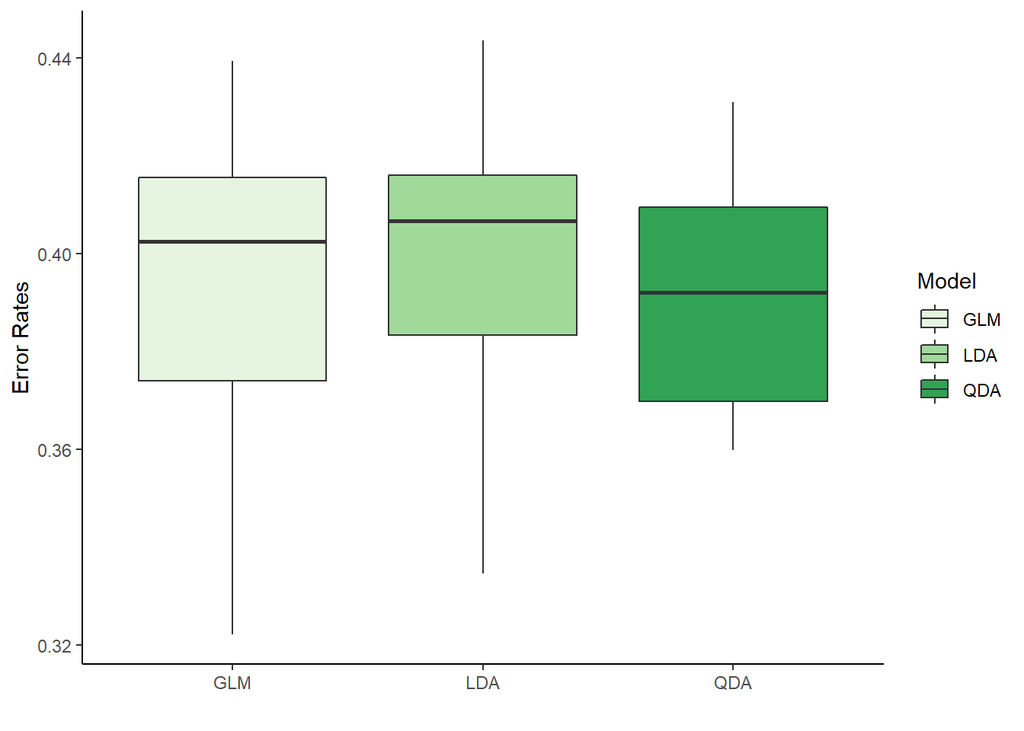

```r
mes<-cbind(me.glm,me.lda,me.qda)
colnames(mes)<-c("GLM","LDA","QDA")
dat2b <- melt(mes, id.vars=1:3)
colnames(dat2b)<-c("Fold","Model","ErrorRate")
bp <- ggplot(dat2b, aes(x=Model, y=ErrorRate, fill=Model)) +
  geom_boxplot()+
  labs( x="",y = "Error Rates")+ theme_classic()+scale_fill_brewer(palette="Greens")
plot(bp)
```